# Risk Factor Analysis

## Outcome Variable

**Outcome Variable:** wast_rec90d

## Predictor Variables

**Intervention Variable:** vagbrth

**Adjustment Set:**

- arm
- sex
- W_mage
- meducyrs
- feducyrs
- hhwealth_quart
- W_mhtcm
- W_mwtkg
- W_mbmi
- single
- W_nrooms
- brthmon
- W_parity
- impfloor
- delta_W_mage
- delta_meducyrs
- delta_feducyrs
- delta_hhwealth_quart
- delta_W_mhtcm
- delta_W_mwtkg
- delta_W_mbmi
- delta_single
- delta_W_nrooms
- delta_brthmon
- delta_W_parity
- delta_impfloor

## Stratifying Variables

The analysis was stratified on these variable(s):

- agecat
- studyid
- country

## Data Summary

| agecat | studyid | country | vagbrth | wast_rec90d | n_cell | n |
| --- | --- | --- | --- | --- | --- | --- |
| 0-24 months | CMC-V-BCS-2002 | INDIA | 0 | 0 | 11 | 324 |
| 0-24 months | CMC-V-BCS-2002 | INDIA | 0 | 1 | 9 | 324 |
| 0-24 months | CMC-V-BCS-2002 | INDIA | 1 | 0 | 109 | 324 |
| 0-24 months | CMC-V-BCS-2002 | INDIA | 1 | 1 | 195 | 324 |
| 0-24 months | IRC | INDIA | 0 | 0 | 24 | 395 |
| 0-24 months | IRC | INDIA | 0 | 1 | 39 | 395 |
| 0-24 months | IRC | INDIA | 1 | 0 | 138 | 395 |
| 0-24 months | IRC | INDIA | 1 | 1 | 194 | 395 |
| 0-24 months | JiVitA-3 | BANGLADESH | 0 | 0 | 206 | 7547 |
| 0-24 months | JiVitA-3 | BANGLADESH | 0 | 1 | 241 | 7547 |
| 0-24 months | JiVitA-3 | BANGLADESH | 1 | 0 | 4152 | 7547 |
| 0-24 months | JiVitA-3 | BANGLADESH | 1 | 1 | 2948 | 7547 |
| 0-24 months | JiVitA-4 | BANGLADESH | 0 | 0 | 84 | 1790 |
| 0-24 months | JiVitA-4 | BANGLADESH | 0 | 1 | 47 | 1790 |
| 0-24 months | JiVitA-4 | BANGLADESH | 1 | 0 | 1208 | 1790 |
| 0-24 months | JiVitA-4 | BANGLADESH | 1 | 1 | 451 | 1790 |
| 0-24 months | NIH-Crypto | BANGLADESH | 0 | 0 | 18 | 189 |
| 0-24 months | NIH-Crypto | BANGLADESH | 0 | 1 | 42 | 189 |
| 0-24 months | NIH-Crypto | BANGLADESH | 1 | 0 | 58 | 189 |
| 0-24 months | NIH-Crypto | BANGLADESH | 1 | 1 | 71 | 189 |
| 0-24 months | PROBIT | BELARUS | 0 | 0 | 62 | 4408 |
| 0-24 months | PROBIT | BELARUS | 0 | 1 | 418 | 4408 |
| 0-24 months | PROBIT | BELARUS | 1 | 0 | 464 | 4408 |
| 0-24 months | PROBIT | BELARUS | 1 | 1 | 3464 | 4408 |
| 0-24 months | PROVIDE | BANGLADESH | 0 | 0 | 25 | 308 |
| 0-24 months | PROVIDE | BANGLADESH | 0 | 1 | 44 | 308 |
| 0-24 months | PROVIDE | BANGLADESH | 1 | 0 | 104 | 308 |
| 0-24 months | PROVIDE | BANGLADESH | 1 | 1 | 135 | 308 |
| 0-24 months | TanzaniaChild2 | TANZANIA, UNITED REPUBLIC OF | 0 | 0 | 24 | 705 |
| 0-24 months | TanzaniaChild2 | TANZANIA, UNITED REPUBLIC OF | 0 | 1 | 32 | 705 |

[output cut: 78 more lines]

The following strata were considered:

- agecat: 0-24 months, studyid: CMC-V-BCS-2002, country: INDIA
- agecat: 0-24 months, studyid: IRC, country: INDIA
- agecat: 0-24 months, studyid: JiVitA-3, country: BANGLADESH
- agecat: 0-24 months, studyid: JiVitA-4, country: BANGLADESH
- agecat: 0-24 months, studyid: NIH-Crypto, country: BANGLADESH
- agecat: 0-24 months, studyid: PROBIT, country: BELARUS
- agecat: 0-24 months, studyid: PROVIDE, country: BANGLADESH
- agecat: 0-24 months, studyid: TanzaniaChild2, country: TANZANIA, UNITED REPUBLIC OF
- agecat: 0-24 months, studyid: ZVITAMBO, country: ZIMBABWE
- agecat: 0-6 months, studyid: CMC-V-BCS-2002, country: INDIA
- agecat: 0-6 months, studyid: IRC, country: INDIA
- agecat: 0-6 months, studyid: JiVitA-3, country: BANGLADESH
- agecat: 0-6 months, studyid: JiVitA-4, country: BANGLADESH
- agecat: 0-6 months, studyid: NIH-Crypto, country: BANGLADESH
- agecat: 0-6 months, studyid: PROBIT, country: BELARUS
- agecat: 0-6 months, studyid: PROVIDE, country: BANGLADESH
- agecat: 0-6 months, studyid: TanzaniaChild2, country: TANZANIA, UNITED REPUBLIC OF
- agecat: 0-6 months, studyid: ZVITAMBO, country: ZIMBABWE
- agecat: 6-24 months, studyid: CMC-V-BCS-2002, country: INDIA
- agecat: 6-24 months, studyid: IRC, country: INDIA
- agecat: 6-24 months, studyid: JiVitA-3, country: BANGLADESH
- agecat: 6-24 months, studyid: JiVitA-4, country: BANGLADESH
- agecat: 6-24 months, studyid: NIH-Crypto, country: BANGLADESH
- agecat: 6-24 months, studyid: PROBIT, country: BELARUS
- agecat: 6-24 months, studyid: PROVIDE, country: BANGLADESH
- agecat: 6-24 months, studyid: TanzaniaChild2, country: TANZANIA, UNITED REPUBLIC OF
- agecat: 6-24 months, studyid: ZVITAMBO, country: ZIMBABWE

### Dropped Strata

Some strata were dropped due to rare outcomes:

- agecat: 0-6 months, studyid: NIH-Crypto, country: BANGLADESH
- agecat: 6-24 months, studyid: CMC-V-BCS-2002, country: INDIA
- agecat: 6-24 months, studyid: JiVitA-3, country: BANGLADESH
- agecat: 6-24 months, studyid: PROBIT, country: BELARUS
- agecat: 6-24 months, studyid: PROVIDE, country: BANGLADESH

## Methods Detail

We’re interested in the causal parameters $E[Y_a]$ for all values of $a \in \mathcal{A}$. These parameters represent the mean outcome if, possibly contrary to fact, we intervened to set all units to have $A=a$. Under the randomization and positivity assumptions, these are identified by the statistical parameters $\psi_a=E_W[E_{Y|A,W}(Y|A=a,W)]$. In addition, we’re interested in the mean of $Y$, $E[Y]$ under no intervention (the observed mean). We will estimate these parameters by using SuperLearner to fit the relevant likelihood factors – $E_{Y|A,W}(Y|A=a,W)$ and $p(A=a|W)$, and then updating our likelihood fit using a joint TMLE.

For unadjusted analyses ($W=\{\}$), initial likelihoods were estimated using Lrnr_glm to estimate the simple $E(Y|A)$ and Lrnr_mean to estimate $p(A)$. For adjusted analyses, a small library containing Lrnr_glmnet, Lrnr_xgboost, and Lrnr_mean was used.

Having estimated these parameters, we will then use the delta method to estimate relative risks and attributable risks relative to a prespecified baseline level of $A$.

# Results Detail

## Results Plots

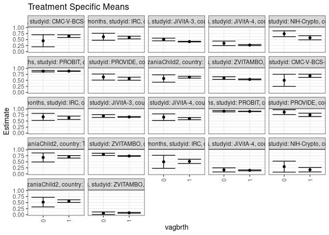

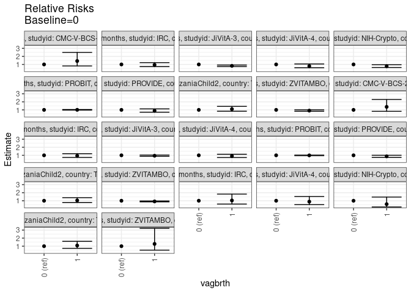

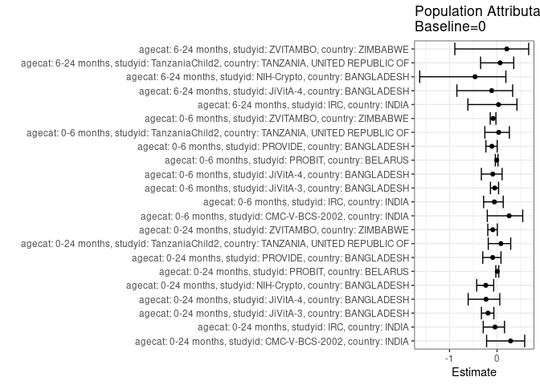

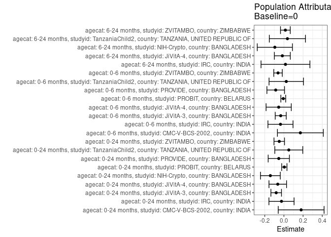

## Results Table

### Parameter: TSM

| agecat | studyid | country | intervention_level | baseline_level | estimate | ci_lower | ci_upper |
| --- | --- | --- | --- | --- | --- | --- | --- |
| 0-24 months | CMC-V-BCS-2002 | INDIA | 0 | NA | 0.4500000 | 0.2010987 | 0.6989013 |
| 0-24 months | CMC-V-BCS-2002 | INDIA | 1 | NA | 0.6414474 | 0.5845014 | 0.6983933 |
| 0-24 months | IRC | INDIA | 0 | NA | 0.6151986 | 0.4703035 | 0.7600938 |
| 0-24 months | IRC | INDIA | 1 | NA | 0.5837655 | 0.5277725 | 0.6397585 |
| 0-24 months | JiVitA-3 | BANGLADESH | 0 | NA | 0.5031652 | 0.4468346 | 0.5594958 |
| 0-24 months | JiVitA-3 | BANGLADESH | 1 | NA | 0.4158192 | 0.4043327 | 0.4273058 |
| 0-24 months | JiVitA-4 | BANGLADESH | 0 | NA | 0.3425996 | 0.2476292 | 0.4375700 |
| 0-24 months | JiVitA-4 | BANGLADESH | 1 | NA | 0.2716351 | 0.2495446 | 0.2937257 |
| 0-24 months | NIH-Crypto | BANGLADESH | 0 | NA | 0.7393391 | 0.6196639 | 0.8590143 |
| 0-24 months | NIH-Crypto | BANGLADESH | 1 | NA | 0.5739032 | 0.4872813 | 0.6605252 |
| 0-24 months | PROBIT | BELARUS | 0 | NA | 0.8764208 | 0.8474318 | 0.9054097 |
| 0-24 months | PROBIT | BELARUS | 1 | NA | 0.8815953 | 0.8715531 | 0.8916375 |
| 0-24 months | PROVIDE | BANGLADESH | 0 | NA | 0.6348249 | 0.5097386 | 0.7599113 |
| 0-24 months | PROVIDE | BANGLADESH | 1 | NA | 0.5677021 | 0.5039894 | 0.6314149 |
| 0-24 months | TanzaniaChild2 | TANZANIA, UNITED REPUBLIC OF | 0 | NA | 0.5748452 | 0.4221771 | 0.7275132 |
| 0-24 months | TanzaniaChild2 | TANZANIA, UNITED REPUBLIC OF | 1 | NA | 0.6297496 | 0.5904595 | 0.6690397 |
| 0-24 months | ZVITAMBO | ZIMBABWE | 0 | NA | 0.5928967 | 0.5358977 | 0.6498956 |
| 0-24 months | ZVITAMBO | ZIMBABWE | 1 | NA | 0.5387288 | 0.5215488 | 0.5559088 |
| 0-6 months | CMC-V-BCS-2002 | INDIA | 0 | NA | 0.5000000 | 0.2484317 | 0.7515683 |
| 0-6 months | CMC-V-BCS-2002 | INDIA | 1 | NA | 0.6864865 | 0.6188619 | 0.7541111 |
| 0-6 months | IRC | INDIA | 0 | NA | 0.6734585 | 0.5279444 | 0.8189726 |
| 0-6 months | IRC | INDIA | 1 | NA | 0.6338043 | 0.5641202 | 0.7034884 |
| 0-6 months | JiVitA-3 | BANGLADESH | 0 | NA | 0.7086817 | 0.6497293 | 0.7676341 |
| 0-6 months | JiVitA-3 | BANGLADESH | 1 | NA | 0.6712579 | 0.6573548 | 0.6851610 |
| 0-6 months | JiVitA-4 | BANGLADESH | 0 | NA | 0.6605740 | 0.5231493 | 0.7979987 |
| 0-6 months | JiVitA-4 | BANGLADESH | 1 | NA | 0.6005809 | 0.5557505 | 0.6454113 |
| 0-6 months | PROBIT | BELARUS | 0 | NA | 0.9076611 | 0.8810434 | 0.9342787 |
| 0-6 months | PROBIT | BELARUS | 1 | NA | 0.9007365 | 0.8911647 | 0.9103083 |
| 0-6 months | PROVIDE | BANGLADESH | 0 | NA | 0.8695652 | 0.7698152 | 0.9693153 |
| 0-6 months | PROVIDE | BANGLADESH | 1 | NA | 0.7553957 | 0.6854609 | 0.8253304 |
| 0-6 months | TanzaniaChild2 | TANZANIA, UNITED REPUBLIC OF | 0 | NA | 0.6800000 | 0.4929570 | 0.8670430 |
| 0-6 months | TanzaniaChild2 | TANZANIA, UNITED REPUBLIC OF | 1 | NA | 0.7064516 | 0.6550297 | 0.7578735 |
| 0-6 months | ZVITAMBO | ZIMBABWE | 0 | NA | 0.8088381 | 0.7624505 | 0.8552258 |
| 0-6 months | ZVITAMBO | ZIMBABWE | 1 | NA | 0.7408778 | 0.7230398 | 0.7587158 |
| 6-24 months | IRC | INDIA | 0 | NA | 0.5000000 | 0.2294903 | 0.7705097 |
| 6-24 months | IRC | INDIA | 1 | NA | 0.5179856 | 0.4297875 | 0.6061838 |
| 6-24 months | JiVitA-4 | BANGLADESH | 0 | NA | 0.1643085 | 0.0779106 | 0.2507063 |
| 6-24 months | JiVitA-4 | BANGLADESH | 1 | NA | 0.1460626 | 0.1263571 | 0.1657681 |
| 6-24 months | NIH-Crypto | BANGLADESH | 0 | NA | 0.3000000 | 0.0725547 | 0.5274453 |
| 6-24 months | NIH-Crypto | BANGLADESH | 1 | NA | 0.1724138 | 0.0793318 | 0.2654957 |
| 6-24 months | TanzaniaChild2 | TANZANIA, UNITED REPUBLIC OF | 0 | NA | 0.5177389 | 0.3200835 | 0.7153942 |
| 6-24 months | TanzaniaChild2 | TANZANIA, UNITED REPUBLIC OF | 1 | NA | 0.5601152 | 0.5055349 | 0.6146956 |
| 6-24 months | ZVITAMBO | ZIMBABWE | 0 | NA | 0.0588235 | 0.0060316 | 0.1116154 |
| 6-24 months | ZVITAMBO | ZIMBABWE | 1 | NA | 0.0753012 | 0.0590916 | 0.0915108 |

### Parameter: E(Y)

| agecat | studyid | country | intervention_level | baseline_level | estimate | ci_lower | ci_upper |
| --- | --- | --- | --- | --- | --- | --- | --- |
| 0-24 months | CMC-V-BCS-2002 | INDIA | NA | NA | 0.6296296 | 0.5734927 | 0.6857666 |
| 0-24 months | IRC | INDIA | NA | NA | 0.5898734 | 0.5376978 | 0.6420491 |
| 0-24 months | JiVitA-3 | BANGLADESH | NA | NA | 0.4225520 | 0.4114127 | 0.4336913 |
| 0-24 months | JiVitA-4 | BANGLADESH | NA | NA | 0.2782123 | 0.2567662 | 0.2996583 |
| 0-24 months | NIH-Crypto | BANGLADESH | NA | NA | 0.5978836 | 0.5264156 | 0.6693516 |
| 0-24 months | PROBIT | BELARUS | NA | NA | 0.8806715 | 0.8711794 | 0.8901636 |
| 0-24 months | PROVIDE | BANGLADESH | NA | NA | 0.5811688 | 0.5245443 | 0.6377934 |
| 0-24 months | TanzaniaChild2 | TANZANIA, UNITED REPUBLIC OF | NA | NA | 0.6255319 | 0.5876598 | 0.6634040 |
| 0-24 months | ZVITAMBO | ZIMBABWE | NA | NA | 0.5441094 | 0.5276459 | 0.5605730 |
| 0-6 months | CMC-V-BCS-2002 | INDIA | NA | NA | 0.6716418 | 0.6057305 | 0.7375531 |
| 0-6 months | IRC | INDIA | NA | NA | 0.6375000 | 0.5751450 | 0.6998550 |
| 0-6 months | JiVitA-3 | BANGLADESH | NA | NA | 0.6752064 | 0.6618507 | 0.6885622 |
| 0-6 months | JiVitA-4 | BANGLADESH | NA | NA | 0.6058824 | 0.5634305 | 0.6483342 |
| 0-6 months | PROBIT | BELARUS | NA | NA | 0.9008671 | 0.8918443 | 0.9098900 |
| 0-6 months | PROVIDE | BANGLADESH | NA | NA | 0.7837838 | 0.7252863 | 0.8422812 |
| 0-6 months | TanzaniaChild2 | TANZANIA, UNITED REPUBLIC OF | NA | NA | 0.7044776 | 0.6548846 | 0.7540707 |
| 0-6 months | ZVITAMBO | ZIMBABWE | NA | NA | 0.7473011 | 0.7302821 | 0.7643201 |
| 6-24 months | IRC | INDIA | NA | NA | 0.5161290 | 0.4322562 | 0.6000019 |
| 6-24 months | JiVitA-4 | BANGLADESH | NA | NA | 0.1476563 | 0.1284384 | 0.1668741 |
| 6-24 months | NIH-Crypto | BANGLADESH | NA | NA | 0.2051282 | 0.1132549 | 0.2970015 |
| 6-24 months | TanzaniaChild2 | TANZANIA, UNITED REPUBLIC OF | NA | NA | 0.5540541 | 0.5015831 | 0.6065250 |
| 6-24 months | ZVITAMBO | ZIMBABWE | NA | NA | 0.0740056 | 0.0585029 | 0.0895082 |

### Parameter: RR

| agecat | studyid | country | intervention_level | baseline_level | estimate | ci_lower | ci_upper |
| --- | --- | --- | --- | --- | --- | --- | --- |
| 0-24 months | CMC-V-BCS-2002 | INDIA | 0 | 0 | 1.0000000 | 1.0000000 | 1.0000000 |
| 0-24 months | CMC-V-BCS-2002 | INDIA | 1 | 0 | 1.4254386 | 0.8141162 | 2.4958048 |
| 0-24 months | IRC | INDIA | 0 | 0 | 1.0000000 | 1.0000000 | 1.0000000 |
| 0-24 months | IRC | INDIA | 1 | 0 | 0.9489058 | 0.7357208 | 1.2238639 |
| 0-24 months | JiVitA-3 | BANGLADESH | 0 | 0 | 1.0000000 | 1.0000000 | 1.0000000 |
| 0-24 months | JiVitA-3 | BANGLADESH | 1 | 0 | 0.8264069 | 0.7364215 | 0.9273880 |
| 0-24 months | JiVitA-4 | BANGLADESH | 0 | 0 | 1.0000000 | 1.0000000 | 1.0000000 |
| 0-24 months | JiVitA-4 | BANGLADESH | 1 | 0 | 0.7928647 | 0.5938568 | 1.0585624 |
| 0-24 months | NIH-Crypto | BANGLADESH | 0 | 0 | 1.0000000 | 1.0000000 | 1.0000000 |
| 0-24 months | NIH-Crypto | BANGLADESH | 1 | 0 | 0.7762382 | 0.6209692 | 0.9703312 |
| 0-24 months | PROBIT | BELARUS | 0 | 0 | 1.0000000 | 1.0000000 | 1.0000000 |
| 0-24 months | PROBIT | BELARUS | 1 | 0 | 1.0059042 | 0.9713294 | 1.0417097 |
| 0-24 months | PROVIDE | BANGLADESH | 0 | 0 | 1.0000000 | 1.0000000 | 1.0000000 |
| 0-24 months | PROVIDE | BANGLADESH | 1 | 0 | 0.8942657 | 0.7116782 | 1.1236976 |
| 0-24 months | TanzaniaChild2 | TANZANIA, UNITED REPUBLIC OF | 0 | 0 | 1.0000000 | 1.0000000 | 1.0000000 |
| 0-24 months | TanzaniaChild2 | TANZANIA, UNITED REPUBLIC OF | 1 | 0 | 1.0955117 | 0.8339797 | 1.4390590 |
| 0-24 months | ZVITAMBO | ZIMBABWE | 0 | 0 | 1.0000000 | 1.0000000 | 1.0000000 |
| 0-24 months | ZVITAMBO | ZIMBABWE | 1 | 0 | 0.9086386 | 0.8216093 | 1.0048866 |
| 0-6 months | CMC-V-BCS-2002 | INDIA | 0 | 0 | 1.0000000 | 1.0000000 | 1.0000000 |
| 0-6 months | CMC-V-BCS-2002 | INDIA | 1 | 0 | 1.3729730 | 0.8222475 | 2.2925636 |
| 0-6 months | IRC | INDIA | 0 | 0 | 1.0000000 | 1.0000000 | 1.0000000 |
| 0-6 months | IRC | INDIA | 1 | 0 | 0.9411186 | 0.7381737 | 1.1998589 |
| 0-6 months | JiVitA-3 | BANGLADESH | 0 | 0 | 1.0000000 | 1.0000000 | 1.0000000 |
| 0-6 months | JiVitA-3 | BANGLADESH | 1 | 0 | 0.9471924 | 0.8694019 | 1.0319433 |
| 0-6 months | JiVitA-4 | BANGLADESH | 0 | 0 | 1.0000000 | 1.0000000 | 1.0000000 |
| 0-6 months | JiVitA-4 | BANGLADESH | 1 | 0 | 0.9091803 | 0.7285440 | 1.1346037 |
| 0-6 months | PROBIT | BELARUS | 0 | 0 | 1.0000000 | 1.0000000 | 1.0000000 |
| 0-6 months | PROBIT | BELARUS | 1 | 0 | 0.9923709 | 0.9618983 | 1.0238089 |
| 0-6 months | PROVIDE | BANGLADESH | 0 | 0 | 1.0000000 | 1.0000000 | 1.0000000 |
| 0-6 months | PROVIDE | BANGLADESH | 1 | 0 | 0.8687050 | 0.7496395 | 1.0066819 |
| 0-6 months | TanzaniaChild2 | TANZANIA, UNITED REPUBLIC OF | 0 | 0 | 1.0000000 | 1.0000000 | 1.0000000 |
| 0-6 months | TanzaniaChild2 | TANZANIA, UNITED REPUBLIC OF | 1 | 0 | 1.0388994 | 0.7816335 | 1.3808416 |
| 0-6 months | ZVITAMBO | ZIMBABWE | 0 | 0 | 1.0000000 | 1.0000000 | 1.0000000 |
| 0-6 months | ZVITAMBO | ZIMBABWE | 1 | 0 | 0.9159779 | 0.8622416 | 0.9730631 |
| 6-24 months | IRC | INDIA | 0 | 0 | 1.0000000 | 1.0000000 | 1.0000000 |
| 6-24 months | IRC | INDIA | 1 | 0 | 1.0359712 | 0.5874383 | 1.8269773 |
| 6-24 months | JiVitA-4 | BANGLADESH | 0 | 0 | 1.0000000 | 1.0000000 | 1.0000000 |
| 6-24 months | JiVitA-4 | BANGLADESH | 1 | 0 | 0.8889535 | 0.5166065 | 1.5296714 |
| 6-24 months | NIH-Crypto | BANGLADESH | 0 | 0 | 1.0000000 | 1.0000000 | 1.0000000 |
| 6-24 months | NIH-Crypto | BANGLADESH | 1 | 0 | 0.5747126 | 0.2266054 | 1.4575764 |
| 6-24 months | TanzaniaChild2 | TANZANIA, UNITED REPUBLIC OF | 0 | 0 | 1.0000000 | 1.0000000 | 1.0000000 |
| 6-24 months | TanzaniaChild2 | TANZANIA, UNITED REPUBLIC OF | 1 | 0 | 1.0818489 | 0.7301434 | 1.6029685 |
| 6-24 months | ZVITAMBO | ZIMBABWE | 0 | 0 | 1.0000000 | 1.0000000 | 1.0000000 |
| 6-24 months | ZVITAMBO | ZIMBABWE | 1 | 0 | 1.2801205 | 0.5086675 | 3.2215712 |

### Parameter: PAR

| agecat | studyid | country | intervention_level | baseline_level | estimate | ci_lower | ci_upper |
| --- | --- | --- | --- | --- | --- | --- | --- |
| 0-24 months | CMC-V-BCS-2002 | INDIA | 0 | NA | 0.1796296 | -0.0595047 | 0.4187640 |
| 0-24 months | IRC | INDIA | 0 | NA | -0.0253252 | -0.1564317 | 0.1057813 |
| 0-24 months | JiVitA-3 | BANGLADESH | 0 | NA | -0.0806132 | -0.1357581 | -0.0254683 |
| 0-24 months | JiVitA-4 | BANGLADESH | 0 | NA | -0.0643873 | -0.1558939 | 0.0271193 |
| 0-24 months | NIH-Crypto | BANGLADESH | 0 | NA | -0.1414555 | -0.2448786 | -0.0380324 |
| 0-24 months | PROBIT | BELARUS | 0 | NA | 0.0042507 | -0.0231102 | 0.0316117 |
| 0-24 months | PROVIDE | BANGLADESH | 0 | NA | -0.0536561 | -0.1643946 | 0.0570825 |
| 0-24 months | TanzaniaChild2 | TANZANIA, UNITED REPUBLIC OF | 0 | NA | 0.0506867 | -0.0953107 | 0.1966842 |
| 0-24 months | ZVITAMBO | ZIMBABWE | 0 | NA | -0.0487872 | -0.1033849 | 0.0058104 |
| 0-6 months | CMC-V-BCS-2002 | INDIA | 0 | NA | 0.1716418 | -0.0677857 | 0.4110693 |
| 0-6 months | IRC | INDIA | 0 | NA | -0.0359585 | -0.1667002 | 0.0947832 |
| 0-6 months | JiVitA-3 | BANGLADESH | 0 | NA | -0.0334752 | -0.0910947 | 0.0241442 |
| 0-6 months | JiVitA-4 | BANGLADESH | 0 | NA | -0.0546917 | -0.1860955 | 0.0767122 |
| 0-6 months | PROBIT | BELARUS | 0 | NA | -0.0067940 | -0.0319871 | 0.0183992 |
| 0-6 months | PROVIDE | BANGLADESH | 0 | NA | -0.0857814 | -0.1775631 | 0.0060003 |
| 0-6 months | TanzaniaChild2 | TANZANIA, UNITED REPUBLIC OF | 0 | NA | 0.0244776 | -0.1550298 | 0.2039850 |
| 0-6 months | ZVITAMBO | ZIMBABWE | 0 | NA | -0.0615370 | -0.1059658 | -0.0171083 |
| 6-24 months | IRC | INDIA | 0 | NA | 0.0161290 | -0.2390237 | 0.2712818 |
| 6-24 months | JiVitA-4 | BANGLADESH | 0 | NA | -0.0166522 | -0.0998343 | 0.0665298 |
| 6-24 months | NIH-Crypto | BANGLADESH | 0 | NA | -0.0948718 | -0.2780930 | 0.0883494 |
| 6-24 months | TanzaniaChild2 | TANZANIA, UNITED REPUBLIC OF | 0 | NA | 0.0363152 | -0.1523927 | 0.2250231 |
| 6-24 months | ZVITAMBO | ZIMBABWE | 0 | NA | 0.0151820 | -0.0357019 | 0.0660660 |

### Parameter: PAF

| agecat | studyid | country | intervention_level | baseline_level | estimate | ci_lower | ci_upper |
| --- | --- | --- | --- | --- | --- | --- | --- |
| 0-24 months | CMC-V-BCS-2002 | INDIA | 0 | NA | 0.2852941 | -0.2199966 | 0.5813066 |
| 0-24 months | IRC | INDIA | 0 | NA | -0.0429333 | -0.2903227 | 0.1570250 |
| 0-24 months | JiVitA-3 | BANGLADESH | 0 | NA | -0.1907771 | -0.3287726 | -0.0671127 |
| 0-24 months | JiVitA-4 | BANGLADESH | 0 | NA | -0.2314323 | -0.6079807 | 0.0569380 |
| 0-24 months | NIH-Crypto | BANGLADESH | 0 | NA | -0.2365937 | -0.4281050 | -0.0707643 |
| 0-24 months | PROBIT | BELARUS | 0 | NA | 0.0048267 | -0.0267318 | 0.0354152 |
| 0-24 months | PROVIDE | BANGLADESH | 0 | NA | -0.0923244 | -0.3005997 | 0.0825980 |
| 0-24 months | TanzaniaChild2 | TANZANIA, UNITED REPUBLIC OF | 0 | NA | 0.0810298 | -0.1850686 | 0.2873778 |
| 0-24 months | ZVITAMBO | ZIMBABWE | 0 | NA | -0.0896644 | -0.1948181 | 0.0062350 |
| 0-6 months | CMC-V-BCS-2002 | INDIA | 0 | NA | 0.2555556 | -0.2051932 | 0.5401588 |
| 0-6 months | IRC | INDIA | 0 | NA | -0.0564054 | -0.2827617 | 0.1300080 |
| 0-6 months | JiVitA-3 | BANGLADESH | 0 | NA | -0.0495778 | -0.1385009 | 0.0324000 |
| 0-6 months | JiVitA-4 | BANGLADESH | 0 | NA | -0.0902678 | -0.3304631 | 0.1065638 |
| 0-6 months | PROBIT | BELARUS | 0 | NA | -0.0075416 | -0.0359002 | 0.0200407 |
| 0-6 months | PROVIDE | BANGLADESH | 0 | NA | -0.1094453 | -0.2348561 | 0.0032289 |
| 0-6 months | TanzaniaChild2 | TANZANIA, UNITED REPUBLIC OF | 0 | NA | 0.0347458 | -0.2569309 | 0.2587375 |
| 0-6 months | ZVITAMBO | ZIMBABWE | 0 | NA | -0.0823457 | -0.1436386 | -0.0243378 |
| 6-24 months | IRC | INDIA | 0 | NA | 0.0312500 | -0.6139924 | 0.4185372 |
| 6-24 months | JiVitA-4 | BANGLADESH | 0 | NA | -0.1127770 | -0.8451479 | 0.3289033 |
| 6-24 months | NIH-Crypto | BANGLADESH | 0 | NA | -0.4625000 | -1.6271554 | 0.1858471 |
| 6-24 months | TanzaniaChild2 | TANZANIA, UNITED REPUBLIC OF | 0 | NA | 0.0655444 | -0.3458018 | 0.3511621 |
| 6-24 months | ZVITAMBO | ZIMBABWE | 0 | NA | 0.2051471 | -0.8882704 | 0.6654127 |